# Practical: Introduction to Phylogenetics in R

## Source

You can find the source files for this tutorial on the class GitHub repository:

https://github.com/EEOB-Macroevolution/EEOB565X-Spring2020/tree/master/practicals/01-intro-to-phylo

## A Brief Introduction to R

### Motivation

R is a statistical programming environment with many built-in mathematical functions and many others that are found in packages that can be installed.

Analyses in R are performed using a series of commands which are written in script files and passed to the main console. The general workflow is:

- 1: OPEN R
- 2: OPEN R-script
- 3: change to working directory
- 4: run analyses

### Some basic commands

Like any programming language, one must learn its syntax. Over time one learns the commands in R, and how to string them together into meaningful operations. Here are some basic commands:

Assign a value to a variable

```r
a <- 3
a
```

```
## [1] 3
```

```r
b = 4
b
```

```
## [1] 4
```

```r
5 -> c
c
```

```
## [1] 5
```

Combine values into a vector (i.e., array) using the `c` function

```r
b <- c(3,4,5)
b
```

```
## [1] 3 4 5
```

Items in a vector can be accessed by calling their position using the `[]` operators. Note that the first element in a vector is assigned position `1`.

```r
b[2]
```

```
## [1] 4
```

Combine objects into a list using the `list` function

```r
l <- list(number = 3, values = c(3.5, 4, 12), message = "many things can go in a list")
l
```

```
## $number
## [1] 3
##
## $values
## [1]  3.5  4.0 12.0
##
## $message
## [1] "many things can go in a list"
```

Items in a list can be accessed by calling their position using the `[[]]` operator, or by calling their name using the `$` operator.

```r
l[[3]]
```

```
## [1] "many things can go in a list"
```

```r
l$message
```

```
## [1] "many things can go in a list"
```

R provides functions for generating random deviates from several different parametric distributions. For example, we can draw a single random value uniformly from the interval (0,1):

```r
x <- runif(1)
x
```

```
## [1] 0.03612023
```

The `rnorm` function lets us draw from a normal distribution. We can draw 50 values from a normal distribution with a mean of 5 and a standard deviation of 1:

```r
a <- rnorm(50,5,1)
```

We can use the `plot()` function to view a simple scatter plot of values in a vector.

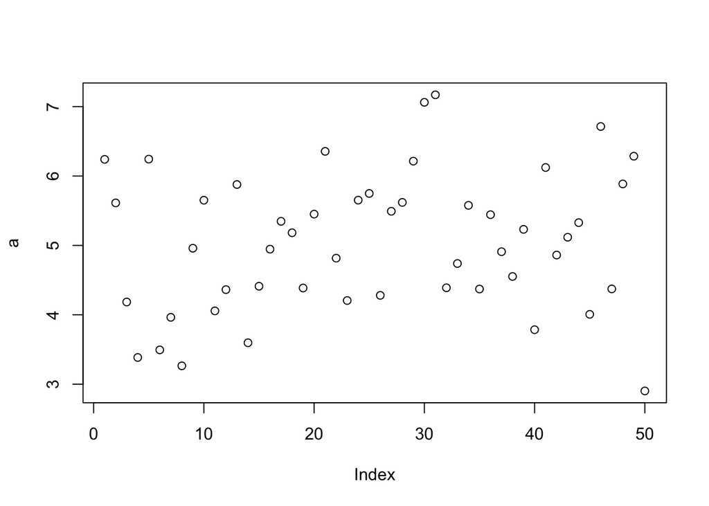

```r
plot(a)
```

And the `hist()` function shows us a histogram of our vector

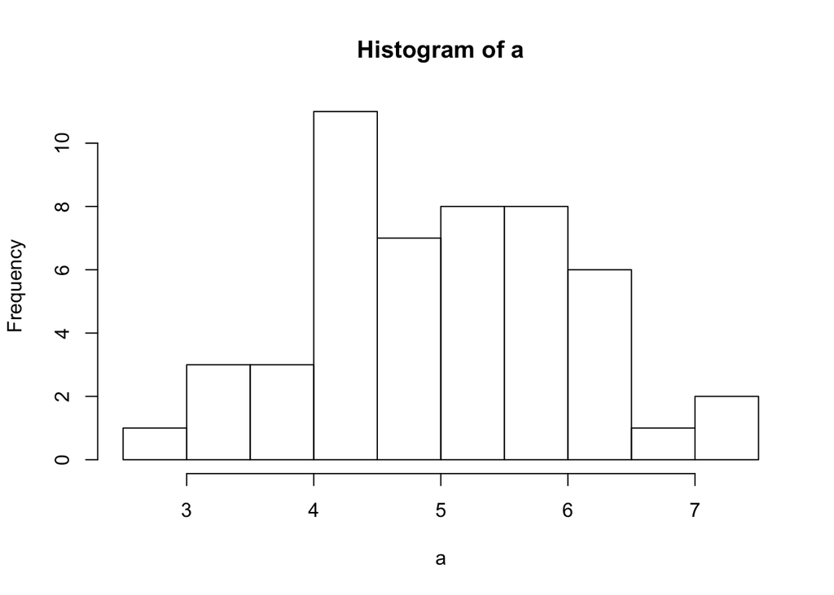

```r
hist(a)
```

There are also several built-in functions that allow us to compute summary statistics of a vector:

```r
mean(a)
```

```
## [1] 5.036668
```

```r
median(a)
```

```
## [1] 5.038755
```

```r
var(a)
```

```
## [1] 1.00608
```

Finally, you can look at the help for any function by calling `?`

```r
?var
```

## Working with Trees using the *ape* Package

The *ape* package provides a structure for storing a phylogenetic tree, as well as basic manipulation and plotting functions. The *ape* structure is used by most R packages which deal with phylogenetic trees, so it is important to understand it.

The first step is to install the package if it is not already

```r
install.packages("ape")
```

and load it into the environment. *ape* is distributed by CRAN, the main package repository for R.

```r
library(ape)
```

### The tree object

*ape* provides functions for simulating random trees with a fixed number of tips, `rcoal` (for ultrametric trees) and `rtree`. These functions can be useful for testing code on a small example, which is what we are going to do here.

```r
tree <- rcoal(5)
```

Let’s take a look at what exactly *ape* created when we asked for a tree:

```r
tree
```

```
##
## Phylogenetic tree with 5 tips and 4 internal nodes.
##
## Tip labels:
## [1] "t3" "t4" "t2" "t1" "t5"
##
## Rooted; includes branch lengths.
```

This tree is of class `phylo`:

```r
class(tree)
```

```
## [1] "phylo"
```

Most phylogenetic packages require `phylo` objects as input.

By opening the tree object in the RStudio environment panel, we can see that this object is in fact a list of several components. The list of these components can also be accessed using the `names` function.

```r
names(tree)
```

```
## [1] "edge"        "edge.length" "tip.label"   "Nnode"
```

```r
tree$edge[1,]
```

```
## [1] 6 8
```

```r
tree$edge.length[1]
```

```
## [1] 0.4913765
```

- `tree$tip.label` is a vector of tip labels, in the same order as the index of those tips in the `edge` matrix (note that in the `phylo` format, tips are required to have indices from 1 to ntips, where ntips is the number of tips). For instance, this is the label of the tip with index 3:

```r
tree$tip.label[3]
```

```
## [1] "t2"
```

- `tree$Nnode` is an integer and contains the number of internal nodes of the tree.
- optionally, there can also be a `tree$node.label` vector which contains labels for all the internal nodes, in the same order as their indices in the `edge` matrix (so if an internal node has index ntips+5, its label is at position 5 in `tree$node.label`).

Most of the time, it is not necessary to directly edit the structure of `phylo` objects, as the *ape* package and others provide functions to manipulate trees.

### Reading and writing trees

In order to interface with other software, or reuse data, we need to be able to input trees from a file, and in reverse to output trees to a file. *ape* supports two formats for input/output of trees, the Newick and the Nexus format. Let’s write our example tree to a Newick file:

```r
write.tree(tree, file = "newick.tre")
```

Opening the file `newick.tre` shows that the tree has been written as a Newick string. We can read that file again into the R environment:

```r
newick_tree <- read.tree("newick.tre")
```

Opening both `tree` and `newick_tree` in the environment panel of RStudio shows that they are indeed the same tree. Similarly, we can write our tree to a Nexus file,

```r
write.nexus(tree, file = "nexus.nex")
```

as well as read it back in.

```r
nexus_tree <- read.nexus("nexus.nex")
```

Again, this tree is identical to the original.

### Plotting trees

Visualizing trees is another useful function provided by the *ape* package. By default, trees are plotted as phylograms, with tip labels:

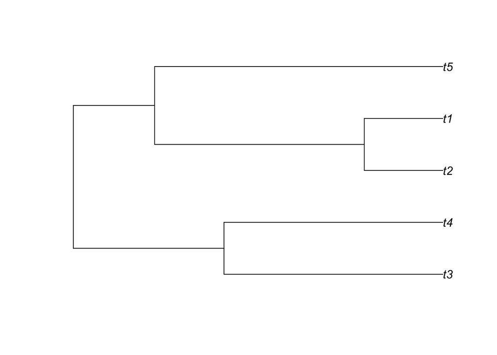

```r
plot(tree)
```

Other options are available, such as coloring the edges

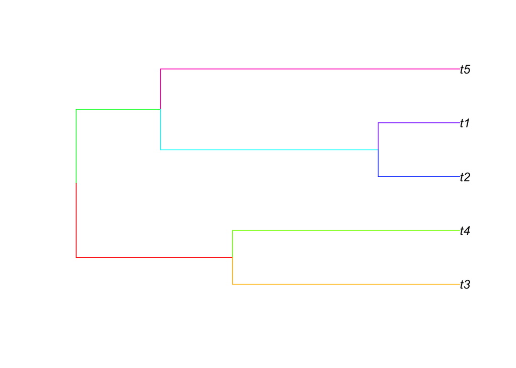

```r
plot(tree, edge.color = rainbow(8))
```

or other types of plots.

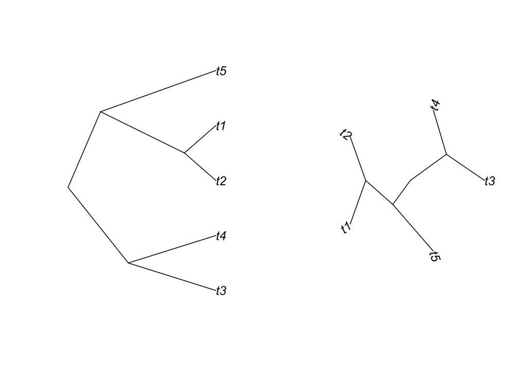

```r
par(mfrow=c(1,2))
plot(tree, type = "cladogram")
plot(tree, type = "radial")
```

Note that many other packages extend the *ape* function or provide their own plotting tools.

### Other useful functions

Some other *ape* functions that can be useful are:

- the `getMRCA` function returns the index of the most recent common ancestor of a group of tips.

```r
getMRCA(tree, c("t1", "t3"))
```

```
## [1] 6
```

- the `node.depth.edgelength` function calculates the depth of each node using the edge lengths.

```r
node.depth.edgelength(tree)
```

```
## [1] 1.2056487 1.2056487 1.2056487 1.2056487 1.2056487 0.0000000 0.2650969
## [8] 0.4913765 0.9491907
```

Note that these are depths, i.e. the root is at d=0. In order to obtain the times, with the present at t=0, the values need to be reversed.

```r
depths <- node.depth.edgelength(tree)
max(depths) - depths
```

```
## [1] 0.0000000 0.0000000 0.0000000 0.0000000 0.0000000 1.2056487 0.9405518
## [8] 0.7142721 0.2564580
```

## Estimating trees in R

This lesson is based on a tutorial written by Klaus Schliep entitled “[Estimating phylogenetic trees with phangorn](https://rdrr.io/cran/phangorn/f/inst/doc/Trees.pdf)”.

To estimate a phylogeny from DNA sequences, we will use the package [*phangorn*](https://github.com/KlausVigo/phangorn).

```r
install.packages("phangorn")
```

```r
library(phangorn)
```

Note that this is one of the few R packages for estimating phylogenies. Typically, researchers use other tools for this like RAxML, BEAST2, IQTree, RevBayes, PAUP*, etc. These software tools are developed as stand-alone programs and most are not accessible in the R environment. The purpose of this lesson is to walk you through how to estimate a phylogenetic tree using maximum likelihood for a simple dataset. With larger datasets, it is much more practical to use a tool that is actively developed for difficult phylogenetic problems.

### Data File

We will use a common example dataset of 12 species of primates plus two outgroups (cow and mouse). This alignment was assembled by Dr. Masami Hasegawa of the Institute of Statistical Mathematics in Tokyo, from sequencing done by Kenji Hayasaka, Takashi Gojobori, and Satoshi Horai (Molecular Biology and Evolution 5: 626-644, 1988). For more details, see [J. Felsenstein’s website](http://evolution.gs.washington.edu/gs570/2016/#data).

Download the data file using R:

```r
download.file("https://raw.githubusercontent.com/EEOB-Macroevolution/EEOB565X-Spring2020/master/practicals/01-intro-to-phylo/primates.dna","primates.dna")
```

This will download the file `primates.dna` into your current working directory. Now we can read in the file using the function `read.phyDat()`.

```r
primates <- read.phyDat("primates.dna", format = "interleaved")
primates
```

```
## 14 sequences with 232 character and 217 different site patterns.
## The states are a c g t
```

### Parsimony

To begin, we will first estimate a tree using parsimony. To perform a heuristic search under parsimony, we can start with a tree built using a random-addition algorithm.

```r
primates_start_tree <- random.addition(primates)
```

First let’s check the parsimony score of our starting tree using the `parsimony()` function:

```r
parsimony(primates_start_tree, primates)
```

```
## [1] 746
```

Now let’s plot the tree.

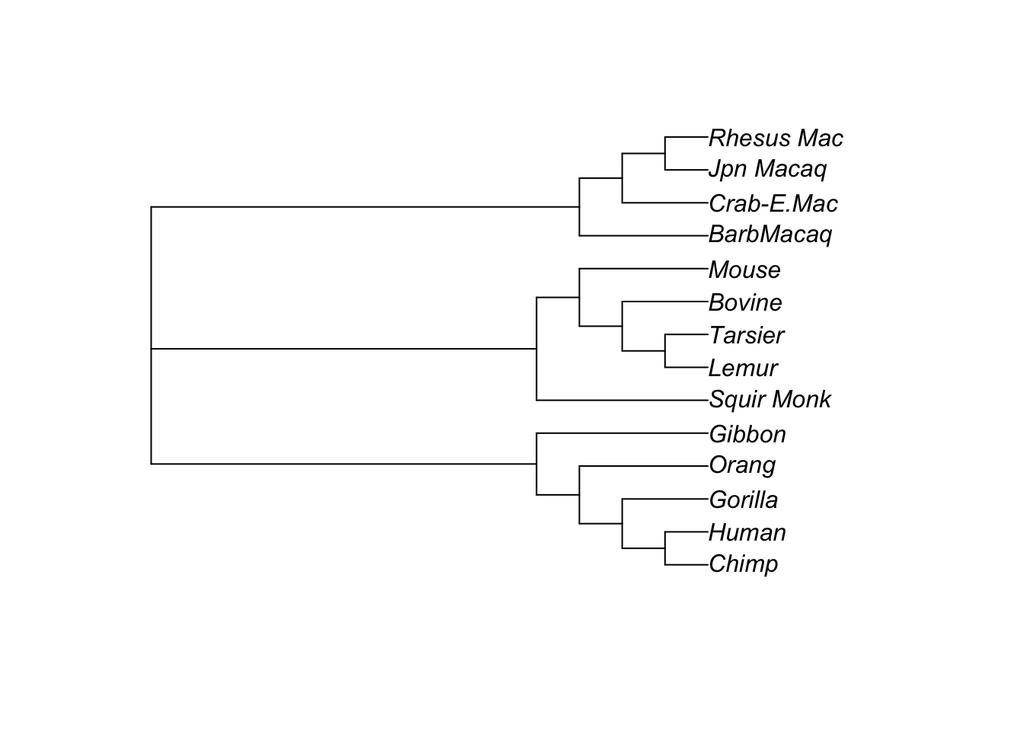

```r
plot(primates_start_tree)
```

You will notice that the tree does not have meaningful branch lengths. We can represent the branch lengths in units of the number of changes (under parsimony) using the `acctran()` function.

```r
primates_start_tree <- acctran(primates_start_tree, primates)
```

The tree should now be depicted as a phylogram where the branch lengths correspond to the number of state changes along a branch.

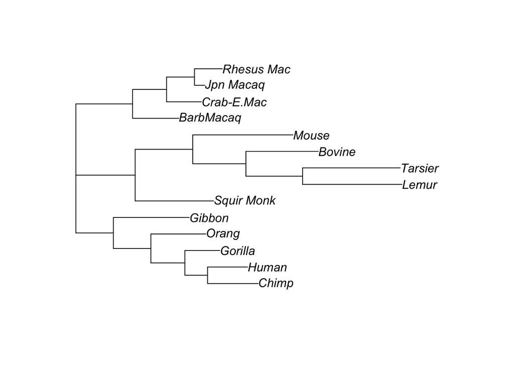

```r
plot(primates_start_tree)
```

Now we can optimize the tree topology under parsimony using the `optim.parsimony()` function. This performs a series of tree rearrangements under NNI.

```r
primates_opt <- optim.parsimony(primates_start_tree, primates)
```

```
## Final p-score 746 after  0 nni operations
```

```r
primates_opt <- acctran(primates_opt, primates)
```

What is the parsimony score of the optimized tree?

```r
parsimony(primates_opt, primates)
```

```
## [1] 746
```

Plot the optimized tree:

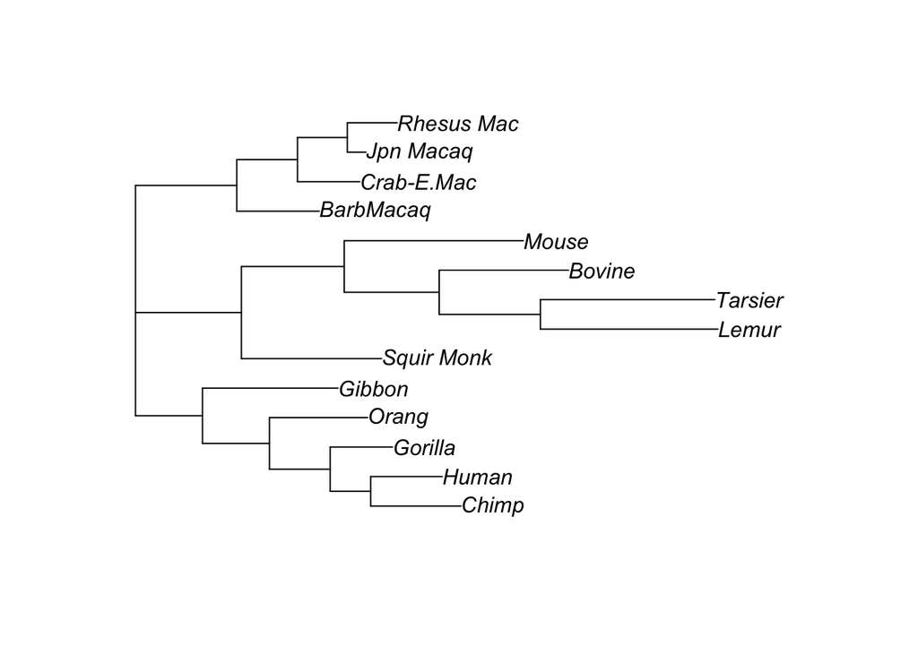

```r
plot(primates_opt)
```

What is different between the starting tree and the optimized tree?

### Maximum Likelihood

Compute the likelihood of the parsimony tree and parsimony branch lengths. For this we use the `pml()` function of *phangorn*. By default, this approach computes the likelihood under the Jukes-Cantor (1969) model:

```r
fitJC <- pml(primates_opt, data=primates)
```

The object `fitJC` contains the parameter estimates and likelihood of the JC model given the data and the tree topology and branch lengths we estimated under parsimony. We can view these values by calling the variable:

```r
fitJC
```

```
##
##  loglikelihood: -4501.298
##
## unconstrained loglikelihood: -1230.335
##
## Rate matrix:
##   a c g t
## a 0 1 1 1
## c 1 0 1 1
## g 1 1 0 1
## t 1 1 1 0
##
## Base frequencies:
## 0.25 0.25 0.25 0.25
```

We do not want to rely on parsimony for the tree topology and branch lengths, but this tree provides a reasonable starting place. We can use the `optim.pml()` function to optimize the tree and model parameters under JC69. This will perform NNI tree rearrangements to identify the topology that maximizes the likelihood.

```r
fitJC <- optim.pml(fitJC, optNni=TRUE)
```

```
## optimize edge weights:  -4501.298 --> -3068.417
## optimize edge weights:  -3068.417 --> -3068.417
## optimize topology:  -3068.417 --> -3068.295
## optimize topology:  -3068.295 --> -3068.295
## 1
## optimize edge weights:  -3068.295 --> -3068.295
## optimize topology:  -3068.295 --> -3068.295
## 0
## optimize edge weights:  -3068.295 --> -3068.295
```

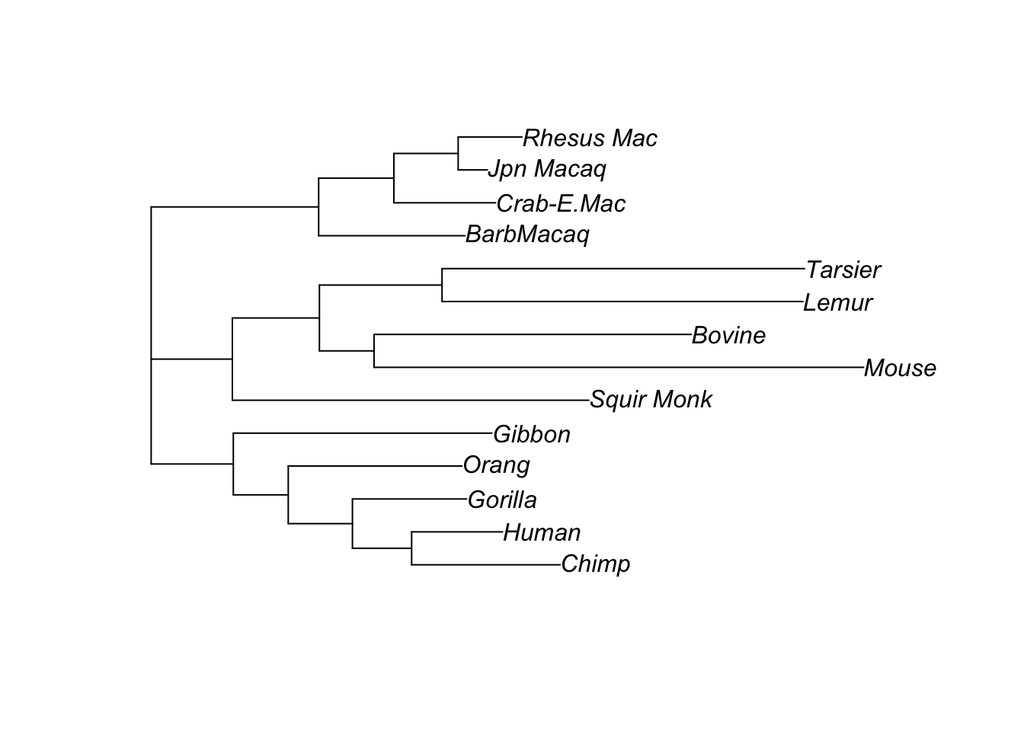

```r
plot(fitJC$tree)
```

The tree is a bit confusing to understand since it is unrooted. Since there are outgroup taxa, we can reroot the tree and present it so that the primates are the ingroup.

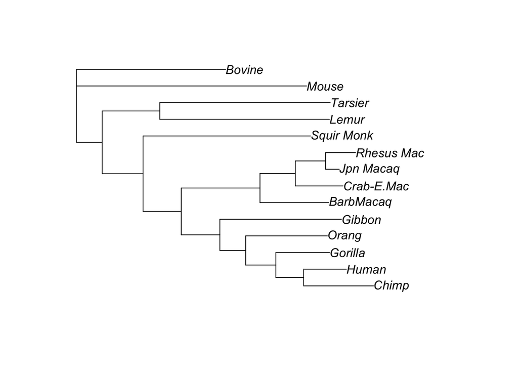

```r
outgroup <- c('Mouse','Bovine')
JC_tree_rooted <- root(fitJC$tree,outgroup)
plot(JC_tree_rooted)
```

If we want to optimize the tree using a different model like GTR, we can use the `pml` object as an argument and specify the `GTR` model.

```r
fitGTR <- optim.pml(fitJC, model="GTR", optNni=TRUE)
```

```
## optimize edge weights:  -3068.295 --> -3068.295
## optimize base frequencies:  -3068.295 --> -2921.276
## optimize rate matrix:  -2921.276 --> -2754.432
## optimize edge weights:  -2754.432 --> -2727.478
## optimize topology:  -2727.478 --> -2726.75
## optimize topology:  -2726.75 --> -2726.75
## 1
## optimize base frequencies:  -2726.75 --> -2706.648
## optimize rate matrix:  -2706.648 --> -2678.367
## optimize edge weights:  -2678.367 --> -2664.708
## optimize topology:  -2664.708 --> -2664.701
## 0
## optimize base frequencies:  -2664.701 --> -2661.117
## optimize rate matrix:  -2661.117 --> -2648.894
## optimize edge weights:  -2648.894 --> -2642.98
## optimize base frequencies:  -2642.98 --> -2642.658
## optimize rate matrix:  -2642.658 --> -2637.455
## optimize edge weights:  -2637.455 --> -2634.122
## optimize base frequencies:  -2634.122 --> -2634.048
## optimize rate matrix:  -2634.048 --> -2631.034
## optimize edge weights:  -2631.034 --> -2628.867
## optimize base frequencies:  -2628.867 --> -2628.821
## optimize rate matrix:  -2628.821 --> -2626.934
## optimize edge weights:  -2626.934 --> -2625.522
```

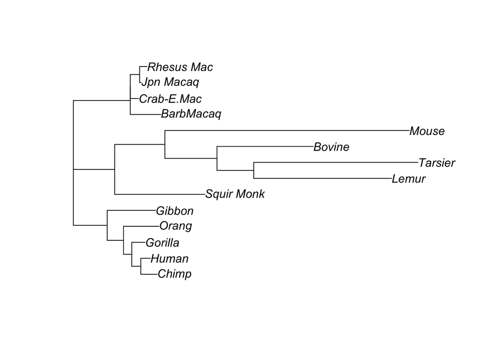

```r
plot(fitGTR$tree)
```

Here the outgroup is not monophyletic, so trying to reroot the tree will give an error

```r
GTR_tree_rooted <- root(fitGTR$tree,outgroup)
```

```
## Error in root.phylo(fitGTR$tree, outgroup): the specified outgroup is not monophyletic
```

View the details of the `fitGTR` object. What is the log-likelihood?

```r
fitGTR
```

```
##
##  loglikelihood: -2625.522
##
## unconstrained loglikelihood: -1230.335
##
## Rate matrix:
##            a           c            g         t
## a  0.0000000 0.424659881 12.263568165 0.3392716
## c  0.4246599 0.000000000  0.006370685 5.8332856
## g 12.2635682 0.006370685  0.000000000 1.0000000
## t  0.3392716 5.833285562  1.000000000 0.0000000
##
## Base frequencies:
## 0.3803178 0.3864315 0.03976639 0.1934843
```

How are the two trees different? What are possible reasons for this ?

One thing that may be bothering you is how do you decide if you should analyze your data under JC69 or under GTR. One option is to compare the models statistically. You can use a likelihood ratio test to compare the two models.

```r
anova(fitJC, fitGTR)
```

```
## Likelihood Ratio Test Table
##   Log lik. Df Df change Diff log lik. Pr(>|Chi|)
## 1  -3068.3 25
## 2  -2625.5 33         8        885.55  < 2.2e-16 ***
## ---
## Signif. codes:  0 '***' 0.001 '**' 0.01 '*' 0.05 '.' 0.1 ' ' 1
```

The results of this comparison show that GTR (model 2) is best supported.

## Calculating the Likelihood of a Tree

In the lecture, you were given the optional challenge to calculate the likelihood of the tree pictured below assuming equal branch lengths and the JC69 model. The next part of this lesson will be to do this in R.

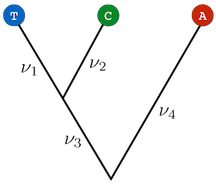

For a detailed explanation, you can see Josh Justison’s solution to the challenge problem here: https://jjustison.github.io/tree-likelihood